# 12 tidy data

LRP

2 April 2020

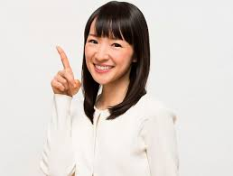

_____________________________________________________________________________________________________

Vamos a hablar de la estructura de los datos, de cómo tienen que estar estructurados para poder hacer análisis fácilmente. …¿Hacer qué análisis fácilmente? Bueno… los que en general se hacen en R. Hay otras versiones de datos no-ordenados que no son “desordenados”, sino que tienen estructuras particulares que sirven para hacer análisis particulares. No vamos a encargarnos de eso hoy.

### Hoy sí vamos a hablar de **datos ordenados** como nombre propio:

un tipo particular de estructura de los datos que lo entiende perfectamente bien R.

En el mundo R pega más el nombre en inglés, que de hecho ayuda a hacer búsquedas de ayuda en estos temas: **tidy data**  
_____________________________________________________________________________________________________

## ¿Cómo es un grupo de datos ordenado?

- cada variable en una columna
- cada observación es una fila
- cada valor está en una celda

Y como la mejor manera de entender es con un ejemplo, vamos a meternos en el ejemplo del libro:

# Datos para trabajar: casos registrados de tuberculosis en Afganistán, Brasil y China en 1999 y 2000 por la OMS.

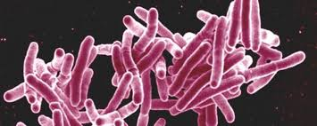

### Existen diferentes maneras de ver los datos:

```r
knitr::kable(tabla1, caption = "tabla1")
```

tabla1

| pais | anio | casos | poblacion |
| --- | --- | --- | --- |
| Afganistán | 1999 | 745 | 19987071 |
| Afganistán | 2000 | 2666 | 20595360 |
| Brasil | 1999 | 37737 | 172006362 |
| Brasil | 2000 | 80488 | 174504898 |
| China | 1999 | 212258 | 1272915272 |
| China | 2000 | 213766 | 1280428583 |

```r
knitr::kable(tabla2,caption = "tabla2")
```

tabla2

| pais | anio | tipo | cuenta |
| --- | --- | --- | --- |
| Afganistán | 1999 | casos | 745 |
| Afganistán | 1999 | población | 19987071 |
| Afganistán | 2000 | casos | 2666 |
| Afganistán | 2000 | población | 20595360 |
| Brasil | 1999 | casos | 37737 |
| Brasil | 1999 | población | 172006362 |
| Brasil | 2000 | casos | 80488 |
| Brasil | 2000 | población | 174504898 |
| China | 1999 | casos | 212258 |
| China | 1999 | población | 1272915272 |
| China | 2000 | casos | 213766 |
| China | 2000 | población | 1280428583 |

```r
knitr::kable(tabla3,caption = "tabla3")
```

tabla3

| pais | anio | tasa |
| --- | --- | --- |
| Afganistán | 1999 | 745/19987071 |
| Afganistán | 2000 | 2666/20595360 |
| Brasil | 1999 | 37737/172006362 |
| Brasil | 2000 | 80488/174504898 |
| China | 1999 | 212258/1272915272 |
| China | 2000 | 213766/1280428583 |

También podemos tener tablas parciales, por ejemplo:

una con la cantidad de casos

```r
knitr::kable(tabla4a, caption = "tabla4a")
```

tabla4a

| pais | 1999 | 2000 |
| --- | --- | --- |
| Afganistán | 745 | 2666 |
| Brasil | 37737 | 80488 |
| China | 212258 | 213766 |

y otra con el tamaño de la población

```r
knitr::kable(tabla4b, caption = "tabla4b")
```

tabla4b

| pais | 1999 | 2000 |
| --- | --- | --- |
| Afganistán | 19987071 | 20595360 |
| Brasil | 172006362 | 174504898 |
| China | 1272915272 | 1280428583 |

La única versión de los datos que es **ordenada** es la tabla 1.

## ¿Por qué es mejor trabajar con datos ordenados?

Ante todo es lo que usan `ggplot2` y `dplyr`

Pero además:

- más fácil de escribir código
- más fácil de reutilizar
- más fácil hacer cálculos

Por ejemplo,

- si queremos calcular la tasa de casos de tuberculosis por cada 10000 habitantes:

```r
tabla1 %>%
  mutate(tasa = casos / poblacion * 10000)
```

```
## # A tibble: 6 x 5
##   pais        anio  casos  poblacion  tasa
##   <chr>      <int>  <int>      <int> <dbl>
## 1 Afganistán  1999    745   19987071 0.373
## 2 Afganistán  2000   2666   20595360 1.29
## 3 Brasil      1999  37737  172006362 2.19
## 4 Brasil      2000  80488  174504898 4.61
## 5 China       1999 212258 1272915272 1.67
## 6 China       2000 213766 1280428583 1.67
```

- si queremos calcular los casos por año

```r
tabla1 %>%
  count(anio, wt = casos)
```

```
## # A tibble: 2 x 2
##    anio      n
##   <int>  <int>
## 1  1999 250740
## 2  2000 296920
```

- o si queremos ver cambios en el tiempo

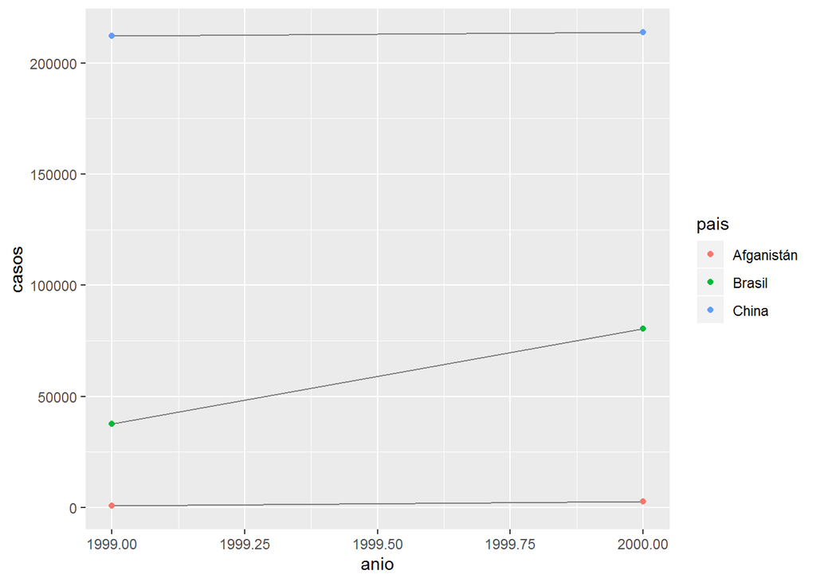

```r
library(ggplot2)
ggplot(tabla1, aes(anio, casos)) +
  geom_line(aes(group = pais), colour = "grey50") +
  geom_point(aes(colour = pais))
```

Todos esos cálculos son directos con la aproximación de los verbos de dplyr, que usan la forma en que R entiende el entorno: vectores de datos como columnas en grupos de datos. Si quisiéramos graficar el cambio en la abundancia poblacional en el tiempo sería tan simple como reemplazar el nombre de la variable en el código ggplot.

```
  escribir/reutilizar/calcular --> tidy data
```

Obtener estos resultados partiendo de las tablas 2, 3, 4a y 4b es realmente más engorroso, y no permite usar los verbos dplyr que aprendimos. Los ejercicios del libro piden hacerlo y ahí se hace evidente que hay que usar subsetting de R base que es bastante menos amable y que quizás no todas sabemos hacer si arrancamos nuestro aprendizaje por **tidyverse**.  
_____________________________________________________________________________________________________

Situación habitual: datos no ordenados… ¿cómo llevarlos a su versión tidy?

# Convertir data en tidy data

Problemas:

- Una variable se extiende por varias columnas
- Una observación está dispersa entre múltiples filas.

## `pivot_longer()`

Miremos de nuevo la tabla 4a

```r
knitr::kable(tabla4a, caption = "tabla4a")
```

tabla4a

| pais | 1999 | 2000 |
| --- | --- | --- |
| Afganistán | 745 | 2666 |
| Brasil | 37737 | 80488 |
| China | 212258 | 213766 |

Problemas: las columnas representan valores que puede tomar una variable, y no una variable. *1999* y *2000* son valores que puede tomar la variable *año* Este verbo me va a permitir fabricar un par de variables: reunir esas dos columnas en una sola que sea la variable que debería ser, y fabricar otra variable que contenga los valores correspondientes.

Necesito:

- el conjunto de columnas que son valores de la variable: acá **1999** y **2000**
- el nombre de la variable que va a agrupar los niveles que están en las columnas, que llamamos `names_to`: en este caso **año**
- el nombre de la variable que va a contener los valores que están en las celdas, que llamamos `values_to`: en este caso: **casos** de tuberculosis

```r
knitr::kable(tabla4a %>%
  pivot_longer(cols = c(`1999`, `2000`), names_to = "año", values_to = "casos"))
```

| pais | año | casos |
| --- | --- | --- |
| Afganistán | 1999 | 745 |
| Afganistán | 2000 | 2666 |
| Brasil | 1999 | 37737 |
| Brasil | 2000 | 80488 |
| China | 1999 | 212258 |
| China | 2000 | 213766 |

Visualmente se vería así:

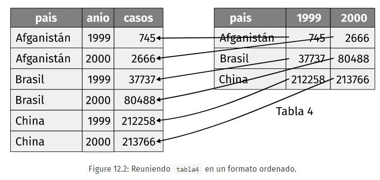

**cosas a tener en cuenta**

- las columnas elegidas son sólo 2, entonces podemos nombrarlas de a una separadas por comas y está bien, pero si fueran más podríamos usar TODOS los criterios que vimos en el capítulo de manipulación de datos con dplyr y `select()`
- los nombres de estas columnas son numéricos, por eso para que se entiendan necesitan el *backtick* (en un df normal y no tibble no podríamos haber usado esos nombres de columna)

Podemos hacer lo mismo con la tabla 4b que tenía el tamaño poblacional de los países

```r
tabla4b %>%
  pivot_longer(cols = c(`1999`,`2000`), names_to = "año", values_to = "casos")
```

```
## # A tibble: 6 x 3
##   pais       año        casos
##   <chr>      <chr>      <int>
## 1 Afganistán 1999    19987071
## 2 Afganistán 2000    20595360
## 3 Brasil     1999   172006362
## 4 Brasil     2000   174504898
## 5 China      1999  1272915272
## 6 China      2000  1280428583
```

```r
knitr::kable(tabla4b%>%
  pivot_longer(cols = c(`1999`,`2000`), names_to = "año", values_to = "casos"), caption = "tabla4b")
```

tabla4b

| pais | año | casos |
| --- | --- | --- |
| Afganistán | 1999 | 19987071 |
| Afganistán | 2000 | 20595360 |
| Brasil | 1999 | 172006362 |
| Brasil | 2000 | 174504898 |
| China | 1999 | 1272915272 |
| China | 2000 | 1280428583 |

```r
tidy4a <- tabla4a %>%
  pivot_longer(cols = c(`1999`,`2000`), names_to = "año", values_to = "casos")

tidy4b <- tabla4b %>%
  pivot_longer(cols = c(`1999`,`2000`), names_to = "año", values_to = "casos")

left_join(tidy4a, tidy4b)
```

```
## # A tibble: 6 x 3
##   pais       año    casos
##   <chr>      <chr>  <int>
## 1 Afganistán 1999     745
## 2 Afganistán 2000    2666
## 3 Brasil     1999   37737
## 4 Brasil     2000   80488
## 5 China      1999  212258
## 6 China      2000  213766
```

```r
knitr::kable(left_join(tidy4a,tidy4b))
```

| pais | año | casos |
| --- | --- | --- |
| Afganistán | 1999 | 745 |
| Afganistán | 2000 | 2666 |
| Brasil | 1999 | 37737 |
| Brasil | 2000 | 80488 |
| China | 1999 | 212258 |
| China | 2000 | 213766 |

[figure not shown]

### versión vieja de esta función: `gather()`

Muy muy parecido y seguirá funcionando al mismo tiempo que `pivot_longer()` por siempre.

Necesito:

- el conjunto de columnas que son valores de la variable: acá **1999** y **2000**
- el nombre de la variable que está repartida en columnas, que llamamos `key`: en este caso **año**
- el nombre de la variable que contiene los valores que están en las celdas, que llamamos `value`: en este caso: **casos** de tuberculosis

```r
tabla4a %>%
  gather(`1999`, `2000`, key = "año", value = "casos")
```

```
## # A tibble: 6 x 3
##   pais       año    casos
##   <chr>      <chr>  <int>
## 1 Afganistán 1999     745
## 2 Brasil     1999   37737
## 3 China      1999  212258
## 4 Afganistán 2000    2666
## 5 Brasil     2000   80488
## 6 China      2000  213766
```

```r
knitr::kable(tabla4a%>%
  gather(`1999`, `2000`, key = "año", value = "casos"), caption = "tabla4a")
```

tabla4a

| pais | año | casos |
| --- | --- | --- |
| Afganistán | 1999 | 745 |
| Brasil | 1999 | 37737 |
| China | 1999 | 212258 |
| Afganistán | 2000 | 2666 |
| Brasil | 2000 | 80488 |
| China | 2000 | 213766 |

Para que las columnas nuevas sean del tipo adecuado (*año* como *character*… queremos *int*) se puede agregar el argumento `convert = TRUE`:

```r
tabla4a %>%
  gather(`1999`, `2000`, key = "año", value = "casos", convert = TRUE)
```

```
## # A tibble: 6 x 3
##   pais         año  casos
##   <chr>      <int>  <int>
## 1 Afganistán  1999    745
## 2 Brasil      1999  37737
## 3 China       1999 212258
## 4 Afganistán  2000   2666
## 5 Brasil      2000  80488
## 6 China       2000 213766
```

Fíjense que las única diferencias son al llamar a las columnas que se van a reunir (separadas por comas en gather, como un vector en pivot_longer) y que en vez de definir la variable que contiene categorías como `key` lo hacemos con la forma más intuitiva `names_to`, y lo mismo con `value` y `values_to`. Así que si ya habían aprendido a usar `gather()` no cambia mucho. Lo que sí cambia es que `pivot_longer` es una versión mejorada de esta forma de reestructurar sets de datos, y entonces permite hacer muchas más cosas que `gather()` no permitía.Por ejemplo, usando `pivot_longer()` es posible definir una estructura compleja de nombres de columnas. Vamos a volver a esto cuando lleguemos al ejemplo al final.

_____________________________________________________________________________________________________

## `pivot_wider()`

Cuando una observación aparece en múltiples filas… Miremos de nuevo la tabla2

```r
knitr::kable(tabla2,caption = "tabla2")
```

tabla2

| pais | anio | tipo | cuenta |
| --- | --- | --- | --- |
| Afganistán | 1999 | casos | 745 |
| Afganistán | 1999 | población | 19987071 |
| Afganistán | 2000 | casos | 2666 |
| Afganistán | 2000 | población | 20595360 |
| Brasil | 1999 | casos | 37737 |
| Brasil | 1999 | población | 172006362 |
| Brasil | 2000 | casos | 80488 |
| Brasil | 2000 | población | 174504898 |
| China | 1999 | casos | 212258 |
| China | 1999 | población | 1272915272 |
| China | 2000 | casos | 213766 |
| China | 2000 | población | 1280428583 |

el problema acá está en las filas: hay información repetida! Hay dos filas para cada país en cada año. Para resolver eso tenemos que *esparcir* esa información, de manera de eliminar el doble registro de cada observación.Queremos que el set de datos que está *largo* pase a estar *ancho*.

Para hacerlo necesitamos sólo 2 elementos:

- el nombre de la columna que contiene a las 2 variables, de donde tomaremos los nombres, de ahí el arggumento `names_from`: en este caso es **tipo**
- el nombre de la columna que contiene los valores de múltiples variables, de donde tomaremos los valores, de ahí el nombre del argumento `values_from`: en este caso es **cuenta**

```r
tabla2 %>%
  pivot_wider(names_from = tipo, values_from = cuenta)
```

```
## # A tibble: 6 x 4
##   pais        anio  casos  población
##   <chr>      <int>  <int>      <int>
## 1 Afganistán  1999    745   19987071
## 2 Afganistán  2000   2666   20595360
## 3 Brasil      1999  37737  172006362
## 4 Brasil      2000  80488  174504898
## 5 China       1999 212258 1272915272
## 6 China       2000 213766 1280428583
```

```r
knitr::kable(tabla2 %>%
  pivot_wider(names_from = tipo, values_from = cuenta))
```

| pais | anio | casos | población |
| --- | --- | --- | --- |
| Afganistán | 1999 | 745 | 19987071 |
| Afganistán | 2000 | 2666 | 20595360 |
| Brasil | 1999 | 37737 | 172006362 |
| Brasil | 2000 | 80488 | 174504898 |
| China | 1999 | 212258 | 1272915272 |
| China | 2000 | 213766 | 1280428583 |

Visualmente hicimos esto:

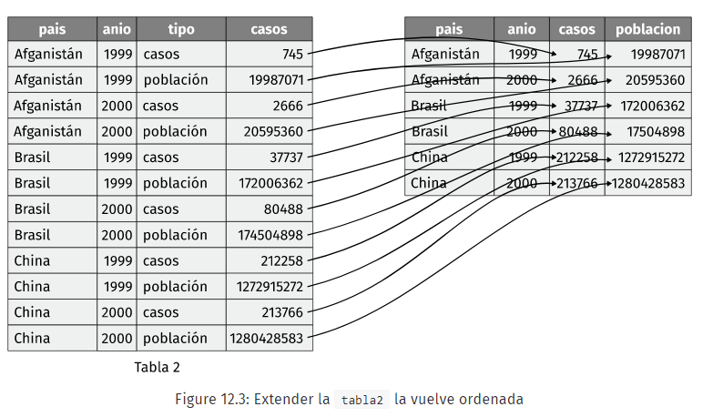

[figure not shown]

### versión vieja de esta función: `spread()`

Para hacerlo necesitamos sólo 2 elementos:

- el nombre de la columna que contiene a las 2 variables, la `key`: en este caso es **tipo**
- el nombre de la columna que contiene los valores de múltiples variables, `value`: en este caso es **cuenta**

```r
tabla2 %>%
  spread(key = tipo, value = cuenta)
```

```
## # A tibble: 6 x 4
##   pais        anio  casos  población
##   <chr>      <int>  <int>      <int>
## 1 Afganistán  1999    745   19987071
## 2 Afganistán  2000   2666   20595360
## 3 Brasil      1999  37737  172006362
## 4 Brasil      2000  80488  174504898
## 5 China       1999 212258 1272915272
## 6 China       2000 213766 1280428583
```

```r
knitr::kable(tabla2 %>%
  spread(key = tipo, value = cuenta))
```

| pais | anio | casos | población |
| --- | --- | --- | --- |
| Afganistán | 1999 | 745 | 19987071 |
| Afganistán | 2000 | 2666 | 20595360 |
| Brasil | 1999 | 37737 | 172006362 |
| Brasil | 2000 | 80488 | 174504898 |
| China | 1999 | 212258 | 1272915272 |
| China | 2000 | 213766 | 1280428583 |

### cosas a tener en cuenta:

pivot_longer y pivot_wider no son exactamente simétricas… mismo ocurre con gather() y spread()

- Cuando usamos `pivot_wider()` los argumentos `names_from` y `values_from` son columnas que existen, que son vectores, y entonces el nombre que usemos es un objeto en R y no necesita comillas. Lo mismo ocurre al usar `spread()` con los argumentos `key` y `value`
- Cuando hacemos un `pivot_longer()` los argumentos `names_to` y `values_to` son objetos que no existen todavía, que se van a crear con el nombre que digamos, entonces sí o sí esos argumentos llevan el nombre que elijamos como secuencia de caracteres entre comillas. Lo mismo ocurre al usar `gather()` con los argumentos `key` y `value`

_____________________________________________________________________________________________________

Más problemas de datos no ordenados:

- una columna contiene 2 variables combinadas
- muchas columnas contienen la información de 1 variables

## `separate()`

Volvamos a la tabla 3

```r
knitr::kable(tabla3)
```

| pais | anio | tasa |
| --- | --- | --- |
| Afganistán | 1999 | 745/19987071 |
| Afganistán | 2000 | 2666/20595360 |
| Brasil | 1999 | 37737/172006362 |
| Brasil | 2000 | 80488/174504898 |
| China | 1999 | 212258/1272915272 |
| China | 2000 | 213766/1280428583 |

Lo que vamos a hacer es simplemente separar el contenido de las celdas según un criterio separador

Necesitamos:

- la columna que contiene las variables combinadas, en esta caso **tasa**
- los nombres de las variables en las que la vamos a separar, por ej.: **casos** y **población**

```r
knitr::kable(tabla3 %>%
  separate(tasa, into = c("casos", "poblacion")))
```

| pais | anio | casos | poblacion |
| --- | --- | --- | --- |
| Afganistán | 1999 | 745 | 19987071 |
| Afganistán | 2000 | 2666 | 20595360 |
| Brasil | 1999 | 37737 | 172006362 |
| Brasil | 2000 | 80488 | 174504898 |
| China | 1999 | 212258 | 1272915272 |
| China | 2000 | 213766 | 1280428583 |

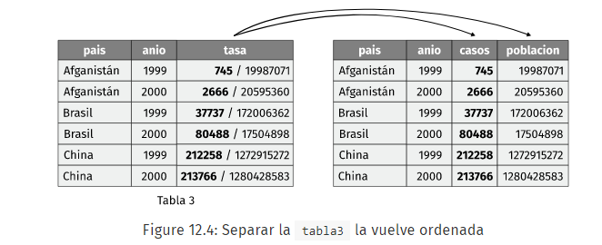

```r
knitr::kable(tabla3 %>%
  separate(tasa, into = c("casos", "poblacion"), sep = "/"))
```

| pais | anio | casos | poblacion |
| --- | --- | --- | --- |
| Afganistán | 1999 | 745 | 19987071 |
| Afganistán | 2000 | 2666 | 20595360 |
| Brasil | 1999 | 37737 | 172006362 |
| Brasil | 2000 | 80488 | 174504898 |
| China | 1999 | 212258 | 1272915272 |
| China | 2000 | 213766 | 1280428583 |

### cosas a tener en cuenta:

- por defecto `separate()` conserva el tipo de dato de la columna original en las 2 nuevas

Como **tasa** era una cadena de caracteres, se mantiene eso en las variables **caso** y **población**.

```r
tabla3 %>%
  separate(tasa, into = c("casos", "poblacion"), sep = "/")
```

```
## # A tibble: 6 x 4
##   pais        anio casos  poblacion
##   <chr>      <int> <chr>  <chr>
## 1 Afganistán  1999 745    19987071
## 2 Afganistán  2000 2666   20595360
## 3 Brasil      1999 37737  172006362
## 4 Brasil      2000 80488  174504898
## 5 China       1999 212258 1272915272
## 6 China       2000 213766 1280428583
```

Podemos hacer lo mismo que hicimos con `gather()` y usar el argumento `convert = TRUE`

```r
tabla3 %>%
  separate(tasa, into = c("casos", "poblacion"), sep = "/", convert = TRUE)
```

```
## # A tibble: 6 x 4
##   pais        anio  casos  poblacion
##   <chr>      <int>  <int>      <int>
## 1 Afganistán  1999    745   19987071
## 2 Afganistán  2000   2666   20595360
## 3 Brasil      1999  37737  172006362
## 4 Brasil      2000  80488  174504898
## 5 China       1999 212258 1272915272
## 6 China       2000 213766 1280428583
```

- también se pueden pasar a `sep` posiciones como números enteros: `separate()` interpreta los enteros como las posiciones donde dividir. Los valores positivos comienzan en 1 al extremo izquierdo de las cadenas de texto; los valores negativos comienzan en -1 al extremo derecho. Al usar enteros para separar cadenas de texto, el largo de `sep` debe ser uno menos que la cantidad de elementos en `into`.

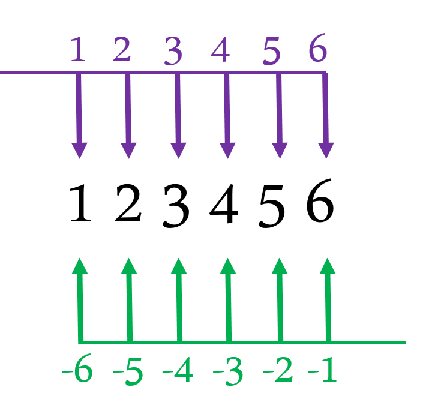

Puedes usar este arreglo para separar los últimos dos dígitos de cada año. Esto deja los datos menos ordenados, pero es útil en otros casos, como se verá más adelante.

```r
tabla3 %>%
  separate(anio, into = c("siglo", "anio"), sep = 2, convert = TRUE)
```

```
## # A tibble: 6 x 4
##   pais       siglo  anio tasa
##   <chr>      <int> <int> <chr>
## 1 Afganistán    19    99 745/19987071
## 2 Afganistán    20     0 2666/20595360
## 3 Brasil        19    99 37737/172006362
## 4 Brasil        20     0 80488/174504898
## 5 China         19    99 212258/1272915272
## 6 China         20     0 213766/1280428583
```

## `unite()`

Es lo opuesto a `separate()` No se usará con tanta frecuencia pero es una herramienta útil llegado el caso. Probemos revertir lo que hicimos en el ejercicio anterior con `separate()` que está guardado en el objeto `tabla5`. Mirémoslo:

```r
knitr::kable(tabla5)
```

| pais | siglo | anio | tasa |
| --- | --- | --- | --- |
| Afganistán | 19 | 99 | 745/19987071 |
| Afganistán | 20 | 00 | 2666/20595360 |
| Brasil | 19 | 99 | 37737/172006362 |
| Brasil | 20 | 00 | 80488/174504898 |
| China | 19 | 99 | 212258/1272915272 |
| China | 20 | 00 | 213766/1280428583 |

Ahora hagamos el `unite()` Los argumentos son el objeto sobre el que vamos a trabajar (**tabla5**), el nombre de la nueva variable (**nueva**) y las columnas que se van a reunir (**siglo**, **anio**).

```r
knitr::kable(tabla5 %>%
  unite(nueva, siglo, anio))
```

| pais | nueva | tasa |
| --- | --- | --- |
| Afganistán | 19_99 | 745/19987071 |
| Afganistán | 20_00 | 2666/20595360 |
| Brasil | 19_99 | 37737/172006362 |
| Brasil | 20_00 | 80488/174504898 |
| China | 19_99 | 212258/1272915272 |
| China | 20_00 | 213766/1280428583 |

Por defecto la combinación se hace usando el separador **_** Si queremos usar otro separador o ninguno, lo podemos especificar en en el argumento `sep`

```r
knitr::kable(tabla5 %>%
  unite(nueva, siglo, anio, sep = ""))
```

| pais | nueva | tasa |
| --- | --- | --- |
| Afganistán | 1999 | 745/19987071 |
| Afganistán | 2000 | 2666/20595360 |
| Brasil | 1999 | 37737/172006362 |
| Brasil | 2000 | 80488/174504898 |
| China | 1999 | 212258/1272915272 |
| China | 2000 | 213766/1280428583 |

### yapas:

1. argumento `remove` por defecto `TRUE`: elimina las columnas originales del objeto final. Cambiando a `FALSE` logramos que las mantenga.
2. cuando no coincide la cantidad de elementos en los que se va a separar con la cantidad de elementos a separar:

así:

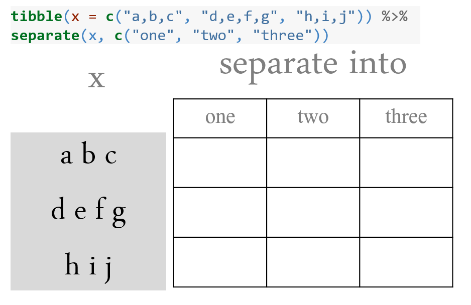

o así:

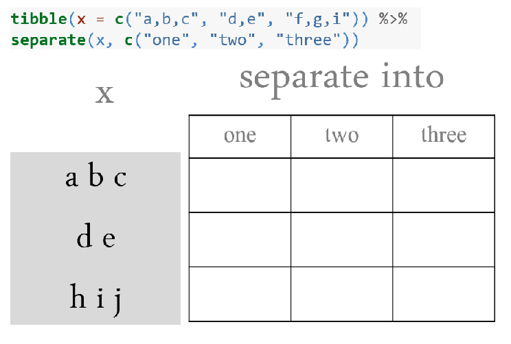

Probemos:

```r
tibble(x = c("a,b,c", "d,e,f,g", "h,i,j")) %>%
  separate(x, c("one", "two", "three"))
```

```
## # A tibble: 3 x 3
##   one   two   three
##   <chr> <chr> <chr>
## 1 a     b     c
## 2 d     e     f
## 3 h     i     j
```

```r
tibble(x = c("a,b,c", "d,e", "f,g,i")) %>%
  separate(x, c("one", "two", "three"))
```

```
## Warning: Expected 3 pieces. Missing pieces filled with `NA` in 1 rows [2].
```

```
## # A tibble: 3 x 3
##   one   two   three
##   <chr> <chr> <chr>
## 1 a     b     c
## 2 d     e     <NA>
## 3 f     g     i
```

los warnings avisan que se hizo algo que no es perfecto. Llenar con los valores de izquierda a derecha: lo que sobra se descarta, lo que falta se completa con NA

Las yapas:

- argumento `extra`: cuando hay más elementos de los esperados le podemos decir cómo trabajarlos.

“drop”: elimina los que sobran sin avisar

“merge”: separa en la cantidad de elementos y junta en la celda final los que sobran

```r
tibble(x = c("a,b,c", "d,e,f,g", "h,i,j")) %>%
  separate(x, c("one", "two", "three"), extra = "merge")
```

```
## # A tibble: 3 x 3
##   one   two   three
##   <chr> <chr> <chr>
## 1 a     b     c
## 2 d     e     f,g
## 3 h     i     j
```

- argumento `fill`: cuando hay menos elementos que los esperados le podemos decir si:

“right”: completa colocando valores faltantes a la derecha

“left”: completa colocando valores faltantes a la izquierda

```r
tibble(x = c("a,b,c", "d,e",   "f,g,i")) %>%
  separate(x, c("one", "two",     "three"), fill = "left")
```

```
## # A tibble: 3 x 3
##   one   two   three
##   <chr> <chr> <chr>
## 1 a     b     c
## 2 <NA>  d     e
## 3 f     g     i
```

1. `extract()`: este argumento sirve para usar grupos de regular expresions y hacer búsquedas más complejas (¿alguien de bases de datos por aquí?)  
   _____________________________________________________________________________________________________

## Valores faltantes

Modificar un grupo de datos conlleva el riesgo de perder datos… Hay 2 tipos de datos faltantes:

- explícitos: aparecen NAs
- implícitos: no existe esa celda

Mirémoslo con un ejemplo

```r
acciones <- tibble(
  anio = c(2015, 2015, 2015, 2015, 2016, 2016, 2016),
  trimestre = c(1, 2, 3, 4, 2, 3, 4),
  retorno = c(1.88, 0.59, 0.35, NA, 0.92, 0.17, 2.66)
)
knitr::kable(acciones)
```

| anio | trimestre | retorno |
| --- | --- | --- |
| 2015 | 1 | 1.88 |
| 2015 | 2 | 0.59 |
| 2015 | 3 | 0.35 |
| 2015 | 4 | NA |
| 2016 | 2 | 0.92 |
| 2016 | 3 | 0.17 |
| 2016 | 4 | 2.66 |

Hay dos datos faltantes en este grupo de datos:

- El 4to trimestre de 2015: `NA` (explícito)
- El 1ero de 2016: no aparece (implícito)

*Un valor faltante explícito es la presencia de una ausencia; un valor faltante implícito es la ausencia de una presencia.*

La forma en que se representa un dataset puede dejar explícitos los valores implícitos.

Por ejemplo, podemos volver explícitos los valores faltantes implícitos al mover los años a las columnas, y luego volver a reunirlos explicitando los valores faltantes:

```r
acciones %>%
  spread(anio, retorno)%>%
  gather(anio, retorno, `2015`:`2016`, na.rm = FALSE)
```

```
## # A tibble: 8 x 3
##   trimestre anio  retorno
##       <dbl> <chr>   <dbl>
## 1         1 2015     1.88
## 2         2 2015     0.59
## 3         3 2015     0.35
## 4         4 2015    NA
## 5         1 2016    NA
## 6         2 2016     0.92
## 7         3 2016     0.17
## 8         4 2016     2.66
```

Si queremos descartar todos los datos faltantes cambiamos el argumento `na.rm = TRUE`

```r
acciones %>%
  spread(anio, retorno)%>%
  gather(anio, retorno, `2015`:`2016`, na.rm = TRUE)
```

```
## # A tibble: 6 x 3
##   trimestre anio  retorno
##       <dbl> <chr>   <dbl>
## 1         1 2015     1.88
## 2         2 2015     0.59
## 3         3 2015     0.35
## 4         2 2016     0.92
## 5         3 2016     0.17
## 6         4 2016     2.66
```

Otra herramienta

## `complete()`

Toma un conjunto de columnas y encuentra todas las combinaciones únicas. Luego se asegura de que el dataset original contenga todos los valores, completando con `NA`s donde sea necesario.

```r
acciones %>%
  complete(anio, trimestre)
```

```
## # A tibble: 8 x 3
##    anio trimestre retorno
##   <dbl>     <dbl>   <dbl>
## 1  2015         1    1.88
## 2  2015         2    0.59
## 3  2015         3    0.35
## 4  2015         4   NA
## 5  2016         1   NA
## 6  2016         2    0.92
## 7  2016         3    0.17
## 8  2016         4    2.66
```

Una más:

## `fill()`

Este lo re conocemos! El famoso *arrastrar celda* de excel para repetir el contenido de la celda. El nombre del método es LOCF, del inglés *last observation carried forward* y básicamente lo que hace es completar copiando el último valor.

Un ejemplo

```r
tratamiento <- tribble(
  ~sujeto, ~tratamiento, ~respuesta,
  "Derrick Whitmore", 1, 7,
  NA, 2, 10,
  NA, 3, 9,
  "Katherine Burke", 1, 4
)

knitr::kable(tratamiento)
```

| sujeto | tratamiento | respuesta |
| --- | --- | --- |
| Derrick Whitmore | 1 | 7 |
| NA | 2 | 10 |
| NA | 3 | 9 |
| Katherine Burke | 1 | 4 |

Para usar `fill()` necesitamos mencionar la variable sobre la que se quiere completar faltantes usando el método de copiar el último valor. En este caso la variable es **sujeto**.

```r
tratamiento %>%
  fill(sujeto)
```

```
## # A tibble: 4 x 3
##   sujeto           tratamiento respuesta
##   <chr>                  <dbl>     <dbl>
## 1 Derrick Whitmore           1         7
## 2 Derrick Whitmore           2        10
## 3 Derrick Whitmore           3         9
## 4 Katherine Burke            1         4
```

```r
knitr::kable(tratamiento %>%
  fill(sujeto))
```

| sujeto | tratamiento | respuesta |
| --- | --- | --- |
| Derrick Whitmore | 1 | 7 |
| Derrick Whitmore | 2 | 10 |
| Derrick Whitmore | 3 | 9 |
| Katherine Burke | 1 | 4 |

### yapas `fill()`

- El argumento `.direction` permite completar con el siguiente valor (`up`), y versiones con el primero de una forma y el resto de otra (`updown` y `downup`).

```r
knitr::kable(tratamiento %>%
  fill(sujeto, .direction = "up"))
```

| sujeto | tratamiento | respuesta |
| --- | --- | --- |
| Derrick Whitmore | 1 | 7 |
| Katherine Burke | 2 | 10 |
| Katherine Burke | 3 | 9 |
| Katherine Burke | 1 | 4 |

- argumento `fill` existe también en `spread()` pero ahí lo que hace es especificar con cuál valor rellenar las celdas que no puedan llenarse con nada. La ventaja de especificarlo es que explicita los missing values implícitos! (resume `spread()` y después `complete()`).

_____________________________________________________________________________________________________

## Estudio de caso

### Tuberculosis: de los datos del sistema de salud a la ciencia de datos

Combinemos todo lo que aprendimos para enfrentar un problema real de ordenamiento de datos. El dataset `datos::oms` contiene datos de tuberculosis (TB) detallados por año, país, edad, sexo y método de diagnóstico. Los datos provienen del *Informe de Tuberculosis de la Organización Mundial de la Salud 2014*, disponible en http://www.who.int/tb/country/data/download/en/.

Existe abundante información epidemiológica en este dataset, pero es complicado trabajar con estos datos tal como son entregados:

```r
oms
```

```
## # A tibble: 7,240 x 60
##    pais  iso2  iso3   anio nuevos_fpp_h014 nuevos_fpp_h1524 nuevos_fpp_h2534
##    <chr> <chr> <chr> <int>           <int>            <int>            <int>
##  1 Afga~ AF    AFG    1980              NA               NA               NA
##  2 Afga~ AF    AFG    1981              NA               NA               NA
##  3 Afga~ AF    AFG    1982              NA               NA               NA
##  4 Afga~ AF    AFG    1983              NA               NA               NA
##  5 Afga~ AF    AFG    1984              NA               NA               NA
##  6 Afga~ AF    AFG    1985              NA               NA               NA
##  7 Afga~ AF    AFG    1986              NA               NA               NA
##  8 Afga~ AF    AFG    1987              NA               NA               NA
##  9 Afga~ AF    AFG    1988              NA               NA               NA
## 10 Afga~ AF    AFG    1989              NA               NA               NA
## # ... with 7,230 more rows, and 53 more variables: nuevos_fpp_h3534 <int>,
## #   nuevos_fpp_h4554 <int>, nuevos_fpp_h5564 <int>, nuevos_fpp_h65 <int>,
## #   nuevos_fpp_m014 <int>, nuevos_fpp_m1524 <int>, nuevos_fpp_m2534 <int>,
## #   nuevos_fpp_m3534 <int>, nuevos_fpp_m4554 <int>, nuevos_fpp_m5564 <int>,
## #   nuevos_fpp_m65 <int>, nuevos_fpn_h014 <int>, nuevos_fpn_h1524 <int>,
## #   nuevos_fpn_h2534 <int>, nuevos_fpn_h3534 <int>, nuevos_fpn_h4554 <int>,
## #   nuevos_fpn_h5564 <int>, nuevos_fpn_h65 <int>, nuevos_fpn_m014 <int>,
## #   nuevos_fpn_m1524 <int>, nuevos_fpn_m2534 <int>, nuevos_fpn_m3534 <int>,
## #   nuevos_fpn_m4554 <int>, nuevos_fpn_m5564 <int>, nuevos_fpn_m65 <int>,
## #   nuevos_ep_h014 <int>, nuevos_ep_h1524 <int>, nuevos_ep_h2534 <int>,
## #   nuevos_ep_h3534 <int>, nuevos_ep_h4554 <int>, nuevos_ep_h5564 <int>,
## #   nuevos_ep_h65 <int>, nuevos_ep_m014 <int>, nuevos_ep_m1524 <int>,
## #   nuevos_ep_m2534 <int>, nuevos_ep_m3534 <int>, nuevos_ep_m4554 <int>,
## #   nuevos_ep_m5564 <int>, nuevos_ep_m65 <int>, nuevosrecaida_h014 <int>,
## #   nuevosrecaida_h1524 <int>, nuevosrecaida_h2534 <int>,
## #   nuevosrecaida_h3534 <int>, nuevosrecaida_h4554 <int>,
## #   nuevosrecaida_h5564 <int>, nuevosrecaida_h65 <int>,
## #   nuevosrecaida_m014 <int>, nuevosrecaida_m1524 <int>,
## #   nuevosrecaida_m2534 <int>, nuevosrecaida_m3534 <int>,
## #   nuevosrecaida_m4554 <int>, nuevosrecaida_m5564 <int>,
## #   nuevosrecaida_m65 <int>
```

La vida misma: columnas redundantes, códigos extraños de variables y muchos valores faltantes. `oms` está desordenado y necesitamos varios pasos para ordenarlo. Al igual que **dplyr**, **tidyr** está diseñado de modo tal que cada función hace bien una cosa. Esto significa que en una situación real deberás encadenar múltiples verbos.

Casi siempre, la mejor forma de comenzar es reunir las columnas que no representan variables. Miremos lo que hay:

- `pais`, `iso2` e `iso3` parecen variables redundantes para **país**.
- `anio` es claramente una variable.
- No sabemos aún el significado de las otras columnas, pero dada la estructura de los nombres de las variables (e.g. `nuevos_fpp_h014`, `nuevos_ep_h014`, `nuevos_ep_m014`) parecieran ser valores y no variables.

Existen múltiples valores faltantes en la representación actual, por lo que de momento usaremos `na.rm` para centrarnos en los valores que están presentes.

```r
oms1 <- oms %>%
  gather(nuevos_fpp_h014:nuevosrecaida_m65, key = "clave", value = "casos", na.rm = TRUE)
oms1
```

```
## # A tibble: 76,046 x 6
##    pais       iso2  iso3   anio clave           casos
##    <chr>      <chr> <chr> <int> <chr>           <int>
##  1 Afganistán AF    AFG    1997 nuevos_fpp_h014     0
##  2 Afganistán AF    AFG    1998 nuevos_fpp_h014    30
##  3 Afganistán AF    AFG    1999 nuevos_fpp_h014     8
##  4 Afganistán AF    AFG    2000 nuevos_fpp_h014    52
##  5 Afganistán AF    AFG    2001 nuevos_fpp_h014   129
##  6 Afganistán AF    AFG    2002 nuevos_fpp_h014    90
##  7 Afganistán AF    AFG    2003 nuevos_fpp_h014   127
##  8 Afganistán AF    AFG    2004 nuevos_fpp_h014   139
##  9 Afganistán AF    AFG    2005 nuevos_fpp_h014   151
## 10 Afganistán AF    AFG    2006 nuevos_fpp_h014   193
## # ... with 76,036 more rows
```

Podemos tener una noción de la estructura de los valores en la nueva columna `clave` si hacemos un conteo:

```r
oms1 %>%
  count(clave)
```

```
## # A tibble: 56 x 2
##    clave               n
##    <chr>           <int>
##  1 nuevos_ep_h014   1038
##  2 nuevos_ep_h1524  1026
##  3 nuevos_ep_h2534  1020
##  4 nuevos_ep_h3534  1024
##  5 nuevos_ep_h4554  1020
##  6 nuevos_ep_h5564  1015
##  7 nuevos_ep_h65    1018
##  8 nuevos_ep_m014   1032
##  9 nuevos_ep_m1524  1021
## 10 nuevos_ep_m2534  1021
## # ... with 46 more rows
```

Podrías resolver esto por tu cuenta pensando y experimentando un poco, pero afortunadamente tenemos el diccionario de datos a mano. Este nos dice lo siguiente:

Necesitamos hacer un pequeño cambio al formato de los nombres de las columnas: desafortunadamente los nombres de las columnas son ligeramente inconsistentes debido a que en lugar de `nuevos_recaida` tenemos `nuevosrecaida`. Aprenderás sobre `str_replace()` en [cadenas de caracteres], pero la idea básica es bastante simple: reemplazar los caracteres “nuevosrecaida” por “nuevos_recaida”. Esto genera nombres de variables consistentes.

```r
oms2 <- oms1 %>%
  mutate(clave = stringr::str_replace(clave, "nuevosrecaida", "nuevos_recaida"))
oms2
```

```
## # A tibble: 76,046 x 6
##    pais       iso2  iso3   anio clave           casos
##    <chr>      <chr> <chr> <int> <chr>           <int>
##  1 Afganistán AF    AFG    1997 nuevos_fpp_h014     0
##  2 Afganistán AF    AFG    1998 nuevos_fpp_h014    30
##  3 Afganistán AF    AFG    1999 nuevos_fpp_h014     8
##  4 Afganistán AF    AFG    2000 nuevos_fpp_h014    52
##  5 Afganistán AF    AFG    2001 nuevos_fpp_h014   129
##  6 Afganistán AF    AFG    2002 nuevos_fpp_h014    90
##  7 Afganistán AF    AFG    2003 nuevos_fpp_h014   127
##  8 Afganistán AF    AFG    2004 nuevos_fpp_h014   139
##  9 Afganistán AF    AFG    2005 nuevos_fpp_h014   151
## 10 Afganistán AF    AFG    2006 nuevos_fpp_h014   193
## # ... with 76,036 more rows
```

Podemos separar los valores en cada código aplicando `separate()` dos veces. La primera aplicación dividirá los códigos en cada `_`.

```r
oms3 <- oms2 %>%
  separate(clave, c("nuevos", "tipo", "sexo_edad"), sep = "_")
oms3
```

```
## # A tibble: 76,046 x 8
##    pais       iso2  iso3   anio nuevos tipo  sexo_edad casos
##    <chr>      <chr> <chr> <int> <chr>  <chr> <chr>     <int>
##  1 Afganistán AF    AFG    1997 nuevos fpp   h014          0
##  2 Afganistán AF    AFG    1998 nuevos fpp   h014         30
##  3 Afganistán AF    AFG    1999 nuevos fpp   h014          8
##  4 Afganistán AF    AFG    2000 nuevos fpp   h014         52
##  5 Afganistán AF    AFG    2001 nuevos fpp   h014        129
##  6 Afganistán AF    AFG    2002 nuevos fpp   h014         90
##  7 Afganistán AF    AFG    2003 nuevos fpp   h014        127
##  8 Afganistán AF    AFG    2004 nuevos fpp   h014        139
##  9 Afganistán AF    AFG    2005 nuevos fpp   h014        151
## 10 Afganistán AF    AFG    2006 nuevos fpp   h014        193
## # ... with 76,036 more rows
```

A continuación podemos eliminar la columna `nuevos`, ya que es constante en este dataset. Además eliminaremos `iso2` e `iso3` ya que son redundantes.

```r
oms3 %>%
  count(nuevos)
```

```
## # A tibble: 1 x 2
##   nuevos     n
##   <chr>  <int>
## 1 nuevos 76046
```

```r
oms4 <- oms3 %>%
  select(-nuevos, -iso2, -iso3)
```

Luego separamos `sexo_edad` en `sexo` y `edad` dividiendo luego del primer carácter:

```r
oms5 <- oms4 %>%
  separate(sexo_edad, c("sexo", "edad"), sep = 1)
oms5
```

```
## # A tibble: 76,046 x 6
##    pais        anio tipo  sexo  edad  casos
##    <chr>      <int> <chr> <chr> <chr> <int>
##  1 Afganistán  1997 fpp   h     014       0
##  2 Afganistán  1998 fpp   h     014      30
##  3 Afganistán  1999 fpp   h     014       8
##  4 Afganistán  2000 fpp   h     014      52
##  5 Afganistán  2001 fpp   h     014     129
##  6 Afganistán  2002 fpp   h     014      90
##  7 Afganistán  2003 fpp   h     014     127
##  8 Afganistán  2004 fpp   h     014     139
##  9 Afganistán  2005 fpp   h     014     151
## 10 Afganistán  2006 fpp   h     014     193
## # ... with 76,036 more rows
```

¡Ahora el dataset `oms` está ordenado!

Hemos mostrado el código parte por parte, asignando los resultados intermedios a nuevas variables. Esta no es la forma típica de trabajo. En cambio, lo que se hace es formar incrementalmente un encadenamiento complejo usando *pipes*:

```r
oms_tidy <- oms %>%
  gather(clave, valor, nuevos_fpp_h014:nuevosrecaida_m65, na.rm = TRUE) %>%
  mutate(clave = stringr::str_replace(clave, "nuevosrecaida", "nuevos_recaida")) %>%
  separate(clave, c("nuevos", "tipo", "sexo_edad")) %>%
  select(-nuevos, -iso2, -iso3) %>%
  separate(sexo_edad, c("sexo", "edad"), sep = 1)
```

```r
knitr::kable(head(oms_tidy))
```

| pais | anio | tipo | sexo | edad | valor |
| --- | --- | --- | --- | --- | --- |
| Afganistán | 1997 | fpp | h | 014 | 0 |
| Afganistán | 1998 | fpp | h | 014 | 30 |
| Afganistán | 1999 | fpp | h | 014 | 8 |
| Afganistán | 2000 | fpp | h | 014 | 52 |
| Afganistán | 2001 | fpp | h | 014 | 129 |
| Afganistán | 2002 | fpp | h | 014 | 90 |

## Estudio de caso usando `pivot_longer()`

Es un poco diferente al que está en el libro. Este ejemplo busca mostrar cómo hacer la interpretación en variables de los nombres de columnas especificando los argumentos de `pivot_longer()`. Es más difícil pero me parece que vale la pena justamente para entender por qué aprender `pivot_longer()` y `pivot_wider()` es superador de los anteriores `gather()` y `spread()`

Cuando tenemos un caso como este del ejemplo, donde las variables están combinadas en códigos de letras, abreviaturas, símbolos, iniciales, etc, sería útil poder separar cada una de esas construcciones en sus componentes, simplemente explicando a qué variable corresponde cada parte.

Uno de los argumentos que podemos especificar en `pivot_longer()` es (justamente!!!) `names_pattern`: permite especificar **en un solo** paso cómo se compone un nombre, y entonces usa esa información para entender en función de qué variables queremos *pivotar* la tabla. Para eso hay que proveer una expresión regular sobre grupos, identificados entre paréntesis. La sintaxis de esto no la puedo explicar con muuucho detalle porque mi entendimiento es superficial, pero la idea es que cada grupo entre paréntesis va a constituir una nueva variable (y columna) y el nombre construido se va a desarmar así:

- empieza textual con “nuevos” y termina (o no) con un “_“. Eso no está entre paréntesis, no forma parte de ningún grupo y entonces no lo vamos a ver en la tabla final. Le estamos diciendo que elimine esa parte de los nombres.
- sigue con el segundo grupo que va a ir a la columna llamada “tipo” que es el primer elemento del vector de `names_to`, y van a ser tooodos los caracteres que aparezcan, sin importar cuáles (el punto) ni cuántos (el asterisco) hasta que llegue al siguiente “_"
- sigue con el segundo grupo que es “sexo”, y va a estar construido por el primer elemento, sea el que sea pero uno (punto solo)
- el último grupo va a estar constituido por todos los caracteres que resten, y se indica entre paréntesis de nuevo con un punto y asterisco.

De esta forma no solo explicamos cómo interpretar las columnas en nuevas variables adecuadas, sino que además eliminamos en un solo paso el problema de la inconsistencia entre formas de llamar a un mismo nivel (con y sin el guión bajo después de “nuevos”) y eliminamos la información invariante “nuevos”.

```r
oms_pl <- oms %>% pivot_longer(
  cols = nuevos_fpp_h014:nuevosrecaida_m65,
  names_to = c("tipo", "sexo", "edad"),
  names_pattern = "nuevos_?(.*)_(.)(.*)",
  values_to = "valor")

knitr::kable(head(oms_pl))
```

| pais | iso2 | iso3 | anio | tipo | sexo | edad | valor |
| --- | --- | --- | --- | --- | --- | --- | --- |
| Afganistán | AF | AFG | 1980 | fpp | h | 014 | NA |
| Afganistán | AF | AFG | 1980 | fpp | h | 1524 | NA |
| Afganistán | AF | AFG | 1980 | fpp | h | 2534 | NA |
| Afganistán | AF | AFG | 1980 | fpp | h | 3534 | NA |
| Afganistán | AF | AFG | 1980 | fpp | h | 4554 | NA |
| Afganistán | AF | AFG | 1980 | fpp | h | 5564 | NA |

¿Qué no hicimos? No eliminamos los NA y eso podemos hacerlo agregando el argumento `values_drop_na = T` a las especificaciones de `pivot_longer()`. Tampoco eliminamos las columnas redundantes del nombre de país, que lo hacemos como antes con un pipe y usando `select()`.

```r
oms_pl_sinNA <- oms %>% pivot_longer(
  cols = nuevos_fpp_h014:nuevosrecaida_m65,
  names_to = c("tipo", "sexo", "edad"),
  names_pattern = "nuevos_?(.*)_(.)(.*)",
  values_to = "valor",
  values_drop_na = TRUE)%>%
  select(-iso2, -iso3)

knitr::kable(head(oms_pl_sinNA))
```

| pais | anio | tipo | sexo | edad | valor |
| --- | --- | --- | --- | --- | --- |
| Afganistán | 1997 | fpp | h | 014 | 0 |
| Afganistán | 1997 | fpp | h | 1524 | 10 |
| Afganistán | 1997 | fpp | h | 2534 | 6 |
| Afganistán | 1997 | fpp | h | 3534 | 3 |
| Afganistán | 1997 | fpp | h | 4554 | 5 |
| Afganistán | 1997 | fpp | h | 5564 | 2 |

Ahora sí, Marie Kondo estaría orgullosa :)